# Cheat Sheet

## Tuple

Tuples are similar to lists in many ways, except they can’t be modified once you’ve created them.

Tuples are defined between two parentheses instead of brackets.

Tuples are iterable but immutable.

```python
tup=("hi", True, 1.0, 2)
tup
```

```
## ('hi', True, 1.0, 2)
```

## Set

A set is an unordered sequence of unique values. ### Creating an empty set

```python
z=set() #creating an empty set
z
```

```
## set()
```

### Set Function

```python
s={1,2,3,3,3,4}
t={8,4,6,2}
s.difference(t)
```

```
## {1, 3}
```

```python
s-t
```

```
## {1, 3}
```

```python
s.intersection(t)
```

```
## {2, 4}
```

```python
s&t
```

```
## {2, 4}
```

```python
s.union(t)
```

```
## {1, 2, 3, 4, 6, 8}
```

```python
s|t
```

```
## {1, 2, 3, 4, 6, 8}
```

```python
s^t
# all non shared items in set
```

```
## {1, 3, 6, 8}
```

## Dictionary

A dictionary is a set of keys with associated values. The key must be hashable, but the value can be any object. It is also known as a hash map, hash table or set of key-value pairs.

```python
thing={}
thing['key1']='val1'
thing[2]='val2'
thing[3]=[3,2,1]
```

Can construct a dictionary from a list or set of tuples

```
dict([('sape', 4139), ('guido', 4127), ('jack', 4098)])
```

### Dictionary functions

```python
thing.keys()
```

```
## dict_keys(['key1', 2, 3])
```

```python
thing.values()
```

```
## dict_values(['val1', 'val2', [3, 2, 1]])
```

```python
thing.items()
```

```
## dict_items([('key1', 'val1'), (2, 'val2'), (3, [3, 2, 1])])
```

```python
thing.get('weight')
# thing.get(<key>, <value>) if key does not exist it will return the input value
```

### Word Frequency Histogram

```python
words=['hi','hello','hi','hi','yo','whazzup','hey','hey']
hist={}
for i in words:
    if i in hist:
        hist[i] += 1
    else:
        hist[i] = 1
hist
```

```
## {'hi': 3, 'hello': 1, 'yo': 1, 'whazzup': 1, 'hey': 2}
```

## Counter

```python
from collections import Counter, defaultdict
sentence = "this is a sentence and it has a bunch of letters and I want to count a few things"
my_counter = Counter(sentence)
my_counter
```

```
## Counter({' ': 18, 't': 9, 'n': 8, 'a': 7, 's': 6, 'e': 6, 'h': 4, 'i': 4, 'c': 3, 'o': 3, 'd': 2, 'u': 2, 'f': 2, 'w': 2, 'b': 1, 'l': 1, 'r': 1, 'I': 1, 'g': 1})
```

## Bitwise Operator

& and | are and and or respectively

```
10 & 1
# is a simple method for determining if an integer is even
```

## Recursion

A function which calls itself

```
def factorial(num):
    prod = 1
    while num > 0:
        prod *= num
        num -+ 1
    return prod
# for a recursive function we need a base case and a recusive call
# with recursion
def factorial_rec(num):
# base case
    if num == 0:
        return 1
# recursive call
    return num * facotrial_rec(num-1)
```

## Yield Statement

The yield statement is similar to return, however, it won’t return the whole result (say a very large list) at the end of the function but a generator instead.

```
def ret(L):
    res = list(map(lambda x: x ** 2, L))
    return res

def gen(L):
    for i in L:
        yield i ** 2
# gives us a generator object
```

we now have a generator and can use the `next` function to return a recursive result

## Web Scraping

example for the following sections:

```
<html>
    <head>
        <title>Hi</title>
    </head>
    <body>
        <a href="https://www.crummy.com/software/BeautifulSoup/">Hello, BeautifulSoup!</a>
    </body>
</html>
```

with regular expressions, parse a file, hi.html and look for all expresions preceeded by `<title> any of letters <title>`

```
import re
hi_path = 'data/hi.html'
with open(hi_path, 'r') as f:
    hi = f.read()
    print(re.findall('<title>(.*)</title>', hi))
```

with beautiful soup

```
from bs4 import BeautifulSoup
with open(hi_path, 'r') as f:
    hi = f.read()
    hi = BeautifulSoup(hi, 'html.parser')
    print(hi.title) # find the title tag
    print(hi.title.string)  # find the value of tag
```

outputs a beautiful soup object

### Names, Values, and Attributes

BeautifulSoup can extract the `name`, `value`, and `attributes` of tags. The corresponding attributes are:  
- `name` - `string` - `attrs`

```
print("The name of a tags is: ", hi.a.name)
print("The value of a tags is: ", hi.a.string)
print("The attribute of a tags is: ", hi.a.attrs)
```

### get_text() & get()

`Hello, BeautifulSoup!`

- The `get()` method is used to extract the value of a specific attribute of a tag. For example, we can get the `href` of the `a` tag using the following code.
- This is the same as running `hi.a.attrs` first and then finding the value of key `href` from the `attrs` dictionary.

```
print(hi.a.get('href'))
```

output: `https://www.crummy.com/software/BeautifulSoup/`

example for the following sections:

```
<html>
    <head>
        <title>Article</title>
    </head>
    <body>
        <h1 id='one'>This is an h1 tag.</h1>
        <p>This is a paragraph, standard size font.</p>
        <h2>This is an h2 tag, smaller font.</h2>
        <p><a href='https://www.google.com'>This is a link to google.</a></p>
        <h3><a href='https://www.yelp.com/'>This is an h3 tag, even smaller.</a></h3>
        <p>And a normal p tag.</p>
    </body>
</html>
```

create a BeautifulSoup object from the article.html

```
article_path = 'data/article.html'
with open(article_path, 'r') as f:
    article = f.read()
    article = BeautifulSoup(article, 'html.parser')
```

### *find()*

- `find()` returns the first `p` tag, which is equivalent to `article.p`:

```
print(article.find('p'))
```

outputs:

This is a paragraph, standard size font.

- `find_all()` returns all descendant `p` tags as a resultset which is a subclass of list:

```
print(article.find_all('p'))
```

- To find the tags that have specific attributes, you can pass a dictionary to the `attrs` argument with the key being the attribute name and the value being the value of the attribute:

```
print(article.find_all('h1', attrs  = {'id':'one'}))
```

output: `[<h1 id="one">This is an h1 tag.</h1>]`

example: The tags whose attribute id == ‘one’

```
print(article.find_all(lambda tag: tag.get('id') == 'one'))
```

output: `[<h1 id="one">This is an h1 tag.</h1>]`

### *Web Scraping Example Books to Scrape*

The general workflow of a web scraping project is the following: 1. Identify which fields we want to scrape. If this means we need to visit different URLs to get to the final page with our relevant information, how do we get those URLs?  
- For this project, we’re interested in the book title, UPC, price, genre, average rating, whether it’s in stock, and how many books available.  
2. Find the unique attributes that will locate the tags of the elements that we’re interested in.  
- What elements are we interested in on the home page? How do we get every element from each search page? What elements do we want on the book pages?  
3. If there are multiple relevant pages in the project, test on the first page to make sure your code is extracting the correct elements.  
- On the first results page, we can try to get all of the `href` attributes from each book product. We should get 20 total because there are 20 books per page.  
4. Once we know that our code is extracting the correct data, we can generalize the code to apply the scraping operations to every page. 5. The final data (the book information) should be stored in a `dict`. This will make saving the data easier.  
6. Once all the `dict` objects are populated, we can save the data locally as a JSON or CSV file (or other formats such as saving to SQL database or pickle file).

```
from bs4 import BeautifulSoup
# request source code format, get request
import requests
# user agent is the software used to acess the site
# google, what is my user agent and copy/paste
headers = {'User-Agent':
           'Mozilla/5.0 (Windows NT 10.0; Win64; x64) AppleWebKit/537.36 (KHTML, like Gecko) Chrome/97.0.4692.99 Safari/537.36'
}
# check the response, 200 is good to go
response = requests.get('https://books.toscrape.com/', headers = headers)
text = BeautifulSoup(response.text, 'html.parser')
```

We can see that each book product has a `div` tag with `class` attribute “image_container.” This tag has a child `a` tag that has an `href` attribute. The `href` attribute value is the URL to each of our book pages.

```
\# We can check the length of the object that is returned to
\# (loosely) confirm that we are getting the correct content
len(text.find_all('div', attrs = {'class': 'image_container'}))
```

```
\# get the child a tags and subsequent href values
\# start with the location of the div tags
book_divs = text.find_all('div', attrs = {'class': 'image_container'})
\# use list comprehension to iterate over each tage to find the child a tag and get the href attribute
book_urls = [tag.find('a').get('href') for tag in book_divs]
print(book_urls[:5])
\# results are missing the domain
```

```
\#concat the domain url to book_urls
complete_book_urls = [f'https://books.toscrape.com/{end_part}' for end_part in book_urls]
print(complete_book_urls[:5])
```

Now we have complete URLs that we can pass to our requests.get() function to retrieve the source code for these book pages. How do we get the URLs for all The Books on the 50 pages of book results?  
Step 3: Find the URL Pattern  
If we click on the “next” button on the bottom right of the page, we’ll see a small change in the URL in our address bar.

- The original URL is: https://books.toscrape.com/
- After we click the next button once, we get: https://books.toscrape.com/catalogue/page-2.html
- If we click the next button again, we get: https://books.toscrape.com/catalogue/page-3.html

Hopefully, you can see the pattern here. After the first page, we have an additional “catalogue/page-X.html” part added to the URL. In fact, if we add this part to the first URL, we should get the first page if we change it to “page-1.”

Try it out: https://books.toscrape.com/catalogue/page-1.html

If we are visiting multiple pages, it is a requirement that the URL changes as well. If we click the “next” button and we see that the URL does **not** change, we would probably need to use another web scraping tool called Selenium which is able to scrape dynamic web elements.

Our goal now is to generate a URL for **every results page**. Since we have identified the pattern, and we can see how many pages there are in total at the bottom of the screen, this should be a simple operation using list comprehension.

```
results_pages = [f'https://books.toscrape.com/catalogue/page-{i}.html' for i in range(1,51)]
print(results_pages[:5])
```

Now that we have all of the URLs for the different results pages, and we have the code to find all the book page URLs for any given page, let’s now move on to getting the data from each book page.

Let’s create another BeautifulSoup object using the source code from a book page. We can use the first book on the first page as an example for testing.

```
response = requests.get('https://books.toscrape.com/catalogue/a-light-in-the-attic_1000/index.html',
                        headers = headers)
text = BeautifulSoup(response.text, 'html.parser')
```

Remember, the fields we are interested in scraping are:

- title
- price
- average rating
- genre
- UPC
- how many books available
- whether the book is in stock

```
# Book title
title = text.find('h1').string
print(title)

# The above only works if this is the first or only h1 tag
# in the entire source code. We can be safer by including
# the parent div tag with it's identifying attribute.
title = text.find('div', attrs = {'class': 'col-sm-6 product_main'}).find('h1').string
print(title)
```

```
# Book price
price_in_pounds = text.find('p', attrs = {'class':'price_color'}).string
print(price_in_pounds)

# Note that there is a strange character before the pounds symbol.
# We will discuss how to handle this later.
```

```
# Average rating
# This one is a little tricky. Where can we find the
# number of stars for the average rating?

# What is this anonymous function doing?
avg_rating_tag = text.find(lambda tag: 'star-rating' in tag.get('class') if tag.get('class') else False)
avg_rating = avg_rating_tag.get('class')
print(avg_rating)

avg_rating = avg_rating[1]
print(avg_rating)

# Note that this is still in string format. We will handle this later.
```

```
# Genre
# Where is the genre of the book located on the page?

li_tag = text.find('ul', attrs = {'class':'breadcrumb'}).find_all('li')[2]
genre = li_tag.find('a').string
print(genre)
```

```
# UPC
# What is the benefit of scraping the UPC code?

# Why is there no tbody tag between the 'table' and 'tr' tags?
# chrome will sometimes add a tbody tag in the inspect view for tables, it is not actually in the source code
tr_tag = text.find('table', attrs = {'class':'table table-striped'}).find_all('tr')[0]
upc = tr_tag.find('td').string
print(upc)
```

```
# How many books are available?
# There are two places where this information is available,
# the tag is easier to indetify in the area by the book title.

num_books_available = text.find('p', attrs = {'class':'instock availability'}).get_text()
print(num_books_available)
```

*Step 5: Bringing the Code Together*

We now have all of the code necessary to scrape all the book page information for every book listed on every results page. Let’s think about how our code should traverse these different levels.

1. Generate a list of results page URLs.
2. Create an empty list to hold the book page URLs.
3. Get the source code for every results page and scrape all of the book page URLs, add these URLs to the URL list (after adding the domain to each URL).
4. After we have all the book page URLs, get the source code for each book page and scrape the relevant information.
5. Store the information in an appropriate data structure.
6. We either save these data structures in a list, or we can write the book information to a CSV file (or use a number of other options for persisting the data).

```
from bs4 import BeautifulSoup
import requests

headers = {'User-Agent': 'Mozilla/5.0 (Windows NT 10.0; Win64; x64) AppleWebKit/537.36 (KHTML, like Gecko) Chrome/88.0.4324.104 Safari/537.36'
            }

# Generate the results page URLs
results_pages = [f'https://books.toscrape.com/catalogue/page-{i}.html' for i in range(1,51)]

# Create empty list to hold book page URLs
book_page_urls = []

# For each results page, scrape the URLs for each book page
for url in results_pages:
    response = requests.get(url, headers=headers)
    text = BeautifulSoup(response.text, 'html.parser')

    if response.status_code != 200:
        raise Exception(f'The status code is not 200! It is {response.status_code}.')

    # Get the book page URLs and add the domain, then add to book page URL list
    book_divs = text.find_all('div', attrs={'class': 'image_container'})
    book_urls = [tag.find('a').get('href') for tag in book_divs]
    complete_book_urls = [f'https://books.toscrape.com/catalogue/{end_part}' for end_part in book_urls]
    # What is the difference between append and extend?
    book_page_urls.extend(complete_book_urls)
```

**Note**: There is another way to approach this process. We could scrape the book page URLs on one results page and then visit every book page to get the book information before moving on to the next results page. Either way is fine, but I prefer to get all the links first and then visit them later.

Let’s now visit each book page and use the code that we tested earlier to get all of the book information.

```
# Create an empty list to hold our book information
book_list = []

# Let's just get the first 100 so this doesn't take very long
for url in book_page_urls[:100]:
    # We'll store our book information in dicitonaries so
    # we should create a new dict for every iteration
    book_dict = {}

    response = requests.get(url, headers = headers)
    text = BeautifulSoup(response.text, 'html.parser')

    if response.status_code != 200:
        raise Exception(f'The status code is not 200! It is {response.status_code}.')

    # Get title
    title = text.find('div', attrs = {'class': 'col-sm-6 product_main'}).find('h1').string
    # Get price
    price_in_pounds = text.find('p', attrs = {'class':'price_color'}).string
    # Get average rating
    avg_rating_tag = text.find(lambda tag: 'star-rating' in tag.get('class') if tag.get('class') else False)
    avg_rating = avg_rating_tag.get('class')[1]
    # Get genre
    li_tag = text.find('ul', attrs={'class':'breadcrumb'}).find_all('li')[2]
    genre = li_tag.find('a').string
    # Get UPC
    tr_tag = text.find('table', attrs = {'class':'table table-striped'}).find_all('tr')[0]
    upc = tr_tag.find('td').string
    # Get number of books available
    num_books_available = text.find('p', attrs = {'class':'instock availability'}).get_text()

    # Store info in the dictionary
    book_dict['title'] = title
    book_dict['price_in_pounds'] = price_in_pounds
    book_dict['avg_rating'] = avg_rating
    book_dict['genre'] = genre
    book_dict['upc'] = upc
    book_dict['num_books_available'] = num_books_available

    # Add dictionary to list
    book_list.append(book_dict)
book_list[:5]
```

*Step 6: Persist the Data*  
Now that we have all of our book information, we need to decide on a way to save our data. There are a few different ways we can save this data:

1. Save to CSV
2. Save to JSON
3. Save to pickle

There are advantages and disadvantages for each format. Let’s talk about them.

*CSV*  
Saving data as a CSV file is probably the most common strategy. CSV (Comma Separated Value) files are a very standard file format (think Excel spreadsheet). We can even load them directly into a pandas DataFrame.

We can use the `csv` module to help us save the data to CSV format. Here is the [documentation](https://docs.python.org/3/library/csv.html).

```
import csv

# Create a new CSV file
with open('books.csv', 'w', encoding = 'utf-8', newline='') as csvfile:
    # Create the CSV writer object
    book_writer = csv.writer(csvfile)
    # Write the initial header row
    book_writer.writerow(['title', 'price_in_pounds', 'avg_rating', 'genre', 'upc', 'num_books_available'])

    # Iterate over the list of dicts and write the values to CSV
    for book_dict in book_list:
        book_writer.writerow(book_dict.values())
```

*JSON* JSON (JavaScript Object Notation) is another file format we can use. You mostly encounter JSON data when working with JavaScript or retrieving data from an API. JSON files look like a list of dictionaries. Often these dictionaries will have nested dictionaries as values. It’s good to know how to work with this file format. Here is the [documentation](https://docs.python.org/3/library/json.html).

```
import json

# This will create a string version of the JSON
# Note the change in encoding for the pound symbol
json.dumps(book_list)

# This will save the JSON to a file
with open('books.json', 'w', encoding = 'utf-8') as jsonfile:
    json.dump(book_list, jsonfile, indent=4)

# To load the JSON back, use the json.load() function
with open('books.json', 'r', encoding = 'utf-8') as jsonfile:
    loaded_books = json.load(jsonfile)
```

*Pickle* Pickle is a way of saving any type of Python object to a file. We can then load this file back into an environment to regain access to the exact same object (in the same state). This is very useful when working with objects that took a long time to create (like a trained machine learning model) or when saving objects in Python that aren’t as obvious to convert into another format. Here is the [documentation](https://docs.python.org/3/library/pickle.html).

```
import pickle

# This will save the object as a pickle
# Note the wb mode here
with open('books.pickle', 'wb') as picklefile:
    pickle.dump(book_list, picklefile)

# This will load the pickle file
# Note the rb mode here
with open('books.pickle', 'rb') as picklefile:
    loaded_books = pickle.load(picklefile)
```

## Arrays

The type ndarray is flexible because it supports a great variety of primitive data types: subject to the homogeneity condition, which means every element in ndarray has the same type.

```python
import numpy as np
nested_lst1 = [[-1,2,1,2],[5,-6,5,6],[7,8,-7,8]]
nested_lst2 = [[1,2,1,2],[5,6,5,6],[7,8,7,8]]
multi_ary1 = np.array(nested_lst1)
multi_ary2 = np.array(nested_lst2)
higher_dim = np.array([multi_ary1, multi_ary2])
higher_dim
```

```
## array([[[-1,  2,  1,  2],
##         [ 5, -6,  5,  6],
##         [ 7,  8, -7,  8]],
##
##        [[ 1,  2,  1,  2],
##         [ 5,  6,  5,  6],
##         [ 7,  8,  7,  8]]])
```

### Array Functions

```python
np.arange(10)
```

```
## array([0, 1, 2, 3, 4, 5, 6, 7, 8, 9])
```

```python
np.arange(2,10) #start, #stop
```

```
## array([2, 3, 4, 5, 6, 7, 8, 9])
```

```python
np.arange(2,10,3) #start, #stop, #step
```

```
## array([2, 5, 8])
```

```python
np.linspace(0,10, 51) #(start, end, no of elements)
```

```
## array([ 0. ,  0.2,  0.4,  0.6,  0.8,  1. ,  1.2,  1.4,  1.6,  1.8,  2. ,
##         2.2,  2.4,  2.6,  2.8,  3. ,  3.2,  3.4,  3.6,  3.8,  4. ,  4.2,
##         4.4,  4.6,  4.8,  5. ,  5.2,  5.4,  5.6,  5.8,  6. ,  6.2,  6.4,
##         6.6,  6.8,  7. ,  7.2,  7.4,  7.6,  7.8,  8. ,  8.2,  8.4,  8.6,
##         8.8,  9. ,  9.2,  9.4,  9.6,  9.8, 10. ])
```

```python
np.ones((3,2)) #(array of ones of dimension 3x2)
```

```
## array([[1., 1.],
##        [1., 1.],
##        [1., 1.]])
```

```python
np.zeros((4,3,2)) #array of zeroes of dimension 4x3x2)
```

```
## array([[[0., 0.],
##         [0., 0.],
##         [0., 0.]],
##
##        [[0., 0.],
##         [0., 0.],
##         [0., 0.]],
##
##        [[0., 0.],
##         [0., 0.],
##         [0., 0.]],
##
##        [[0., 0.],
##         [0., 0.],
##         [0., 0.]]])
```

```python
high_x1 = np.array([[1,2,3],[4,5,6]])
high_x1.shape
```

```
## (2, 3)
```

```python
x = np.arange(8)
x.reshape([2,4], order='F') #reshapes array to 2x4 fills by columns
```

```
## array([[0, 2, 4, 6],
##        [1, 3, 5, 7]])
```

```python
x.astype(float) # change datatype of array elements
```

```
## array([0., 1., 2., 3., 4., 5., 6., 7.])
```

## Matrix

```python
x = np.matrix([3,2])
print(type(x))
```

```
## <class 'numpy.matrix'>
```

```python
print(x.shape)
```

```
## (1, 2)
```

```python
x
```

```
## matrix([[3, 2]])
```

### Matrix Multiplication

The type matrix is for linear algebra, in which the matrix multiplication is always **“a row times a column”**:

$$(1,2,3) \times \left(
\begin{array}{c}
1\\
2\\
3\\
\end{array}
\right)
= (1+4+9) = 14$$
### Identity Matrix

```python
Id = np.matrix(np.eye(3))
Id
```

```
## matrix([[1., 0., 0.],
##         [0., 1., 0.],
##         [0., 0., 1.]])
```

### Inverse Matrix

The identity matrix is analogous to the number one. One is referred to as the multiplicative identity, since any number multiplied by one remains unchanged. A nonzero number has a multiplicative inverse, or reciprocal. The product of a number and its multiplicative inverse is the multiplicative identity, one.

**For real scalars:**

- nonzero number: n
- multiplicative identity: 1
- multiplicative inverse: $\frac{1}{n}$
  $$n \times 1 = n$$

$$n \times \frac{1}{n}=1$$

The analogy for a square matrix is called an inverse matrix. A nonsingular square matrix has a multiplicative inverse, or inverse matrix. The product of a matrix and its inverse matrix (in either order) is the identity matrix.

**For real-valued square matrices:**

- nonsingular matrix: $M$
- identity matrix: $\textbf{1}$
- inverse: $M^{-1}$
  $$M \cdot \textbf{1} = M$$

$$M \cdot M^{-1}=\textbf{1}$$

$$M^{-1} \cdot M=\textbf{1}$$

- How do you find a tuple of `x`, `y` and `z` satisfying all the equations below?
  $$\begin{eqnarray}
  3x +2y -z &= 1\\
  2x -2y +4z &=-2\\
  -x +\frac{1}{2}y- z&= 0
  \end{eqnarray}$$

Observe that the equation can be written as:

$$\begin{pmatrix}
3 &2 &-1 \\
2 &-2 &4 \\
-1&\frac{1}{2}&-1
\end{pmatrix}
\times
\begin{pmatrix}
x\\y\\z
\end{pmatrix}
=
\begin{pmatrix}
1\\-2\\0
\end{pmatrix}$$

$$\begin{pmatrix}
x\\y\\z
\end{pmatrix}=
\begin{pmatrix}
3 &2 &-1 \\
2 &-2 &4 \\
-1&\frac{1}{2}&-1
\end{pmatrix}^{-1} \times
\begin{pmatrix}
1\\-2\\0
\end{pmatrix}$$

```python
M = np.matrix([[3, 2, -1],[2, -2, 4],[-1, 0.5, -1]])
M2 = np.matrix([[1], [-2], [0]])
M.I * M2
```

```
## matrix([[ 1.],
##         [-2.],
##         [-2.]])
```

## Classes

*Attributes and Methods*

- We’ll go into details in a bit, but here is the syntax to define a simple class:

```
class Classname(object):
    def __init__(self):
        initialize representation by assigning to variables

    def methodname(self, ...args...):
        define method;
        change representation or return value or both;
        use self.var to refer to variable var defined in init.
```

- In `__init__`, we assign the desired representation to one or more variables, so we just have to decide what their names will be.
- Once we have this class, we can create instances of it:

```
newobj = Classname()
```

- We invoke methods using object notation:

```
newobj.methodname(...args...)
```

- Note that even though we defined the method using ordinary function definition syntax, we must call it using object syntax. That is just because it is defined inside a class.
- However, in Python, there is an attribute naming convention to denote private attributes by prefixing the attribute with one or two underscores, e.g:

```python
self._coords
self.__coords
```

- `Person` is the **class**
- `name` and `age` are each an **object attribute**
- `say` is an **object method**

```python
class Person():
    '''This is the documentation of the class person ... here'''

    def __init__(self,a_name,a_age):#constructor
        self.name=a_name
        self.age=a_age

    def intro(self):
        print("My name is",self.name,"and I am",self.age,"years old")
```

### *Special Name method*

use the `__str__` special method  
and the `__add__` special method  
second arg in an attribute definition is ussually labeled as `other`

```python
class Vector(object):
    def __init__(self, lis):
        self.coords = lis

    def length(self):
        return sum([x**2 for x in self.coords])**.5

    def __str__(self):
        return 'Vector' + str(self.coords)
    def __add__(self, other):
        return Vector(list(map(lambda x, y: x+y, self.coords, other.coords)))

# Then we print the Vector object:
vec_1 = Vector([1,2,3])
print(vec_1)
```

```
## Vector[1, 2, 3]
```

#### *Exercise*

- Now our Vector class looks like this:

```
class Vector(object):
    def __init__(self, lis):
        self.coords = lis

    def length(self):
        return sum([x**2 for x in self.coords])**.5

    def __add__(self, other):
        return Vector(map(lambda x, y: x+y,
                          self.coords, other.coords))

    def __str__(self):
        return 'Vector'+str(self.coords)
```

- Add two more methods to the class:  
  `__eq__(vec)`: returns `True` if this vector equals `vec`.
- `u == v` calls `u.__eq__(v)`.
- `__mul__(vec)`: returns the dot product of this vector and `vec`. The dot product is defined by: (`x`, `y`, …) `*` (`x’`, `y’`, …) = `xx’ + yy’ +` …
- `u * v` calls `u.__mul__(v)`
- Then evaluate the following expressions ( equality and $cos(\theta)$):

```python
class Vector(object):
    def __init__(self, lis):
        self.coords = lis

    def length(self):
        return sum([x**2 for x in self.coords])**.5

    def __add__(self, other):
        return Vector(list(map(lambda x, y: x+y, self.coords, other.coords)))

    def __str__(self):
        return 'Vector'+str(self.coords)

    def __eq__(self, other):
        return list(self.coords) == list(other.coords)


    def __mul__(self, other):
        return sum(list(map(lambda x,y: x*y, self.coords, other.coords)))
u = Vector([1,1,0])
v = Vector([0,1,1])
print(u == v)
```

```
## False
```

```python
print((u*v) / (u.length()*v.length()))
```

```
## 0.4999999999999999
```

### *Inhereitance*

inherited classes do not need an init statement

```python
class Book(object):
    def __init__(self, name, author = None):
        self.name = name
        self.author = author

    def __str__(self):
        return '<%s> by %s' % (self.name, self.author)
class EBook(Book):
    def __init__(self, name, author = None):
        Book.__init__(self, name, author)
```

create a mutating method

```python
class Book(object):
    def __init__(self, name, author = None):
        self.name = name
        self.author = author
    def __str__(self):
        return '<%s> by %s' %(self.name, self.author)
    def rename(self, newname):
        if not isinstance(newname, str):
            raise TypeError('please enter a valid str value for new name')
        self.name = newname

book_1 = Book('The little SAS book', 'Lora D. Delwiche')
print("The name of book_1 is originally %s" % book_1)
```

```
## The name of book_1 is originally <The little SAS book> by Lora D. Delwiche
```

```python
book_1.rename('The SAS book')
print("The name of book_1 is now %s" % book_1)
```

```
## The name of book_1 is now <The SAS book> by Lora D. Delwiche
```

### *Class Method*

uses the class itself as an argument in a method to return some object

```python
class Date(object):

    def __init__(self, day = 0, month = 0, year = 0):
        self.day = day
        self.month = month
        self.year = year


    @classmethod
    def from_string(cls, date_as_string):
        '''
        This function takes a string as input and returns a Date object.
        The input string needs to follow the format of 'dd-mm-yyyy'
        '''
        day, month, year = list(map(int, date_as_string.split('-')))
        date1 = cls(day, month, year)
        return date1

# usage
date2 = Date.from_string('23-08-1990')
date2.year
```

```
## 1990
```

- We’ve implemented date string parsing in one place and it’s reusable now.
- @classmethod is a special syntax sugar called [decorator](https://realpython.com/blog/python/primer-on-python-decorators/) in Python.
- Decorator takes a function as an input and returns the modified function as the output. i.e. convert the `from_string` function to a class method.
- cls is an object that holds **class itself**, not an instance of the class. It’s pretty cool because if we inherit our Date class, all children will have from_string defined also.

## Regular Expressions

https://learnbyexample.github.io/python-regex-cheatsheet/

### *Meta Characters*

`.^$*+?{}[]\|()`

### *Import and basic methods*

```
import re
raw_string = 'Hi, how are you today?, Hi'
re.search('Hi', raw_string)
print(s.start()) # the starting position of of the matched string
print(s.end())   # the ending position index of the matched string
print(s.span())  # a tuple containing the (start, end) positions of the matched string
print(s.group()) # the matched string
# split by common seperators
print(re.split(re.split('[\n ,.-]+', s))) #Split the string into a list by the pattern.
# find all letters
print(re.findall('[a-zA-Z]+', s)) # Find all substrings where the pattern matches, and return them as a list.
```

### *dot*

`.` refers to any single character  
`a.` matches any 2 characters that start with a

```
print(re.search('a.', 'aa') != None)
print(re.search('a.', 'ab') != None)
print(re.search('a.', 'a1') != None)
print(re.search('a.b', 'a+b') != None)
print(re.search('a.b', 'a+x+b') != None)
print(re.search('../../201.', 'From 06/01/2015') != None)
s = re.search('(..)/(..)/(201.)', 'From 06/01/2015')
print(s.group(1))
```

### *Question mark, plus, asterisk, and {}*

? matches the preceding expression either once or zero times.

+ matches the preceding expression character at least once.

* matches the preceding expression character arbitrary times.

{m,n} matches the preceding expression at least m times and at most n times.

For example, ba?b matches bab and bb.

### *caret / dollar sign*

^ refers to the beginning of a text, while $ refers to the ending of a text.

For example, ^a matches any text that begins with character a.

a$ matches any text ending with character a.

### *bracket*

[] is used to specify a set of characters that you wish to match. For example, [123abc] will match any of the characters 1, 2, 3, a, b, or c ; this is the same as [1-3a-c], which uses a range to express the same set of characters. Further more [a-z] matches all lower letters, while [0-9] matches all numbers.  
Special characters lose their special meaning inside sets. For example, [(+*)] will match any of the literal characters ‘(’, ‘+’, ’*‘, or’)‘.  
Characters that are not within a range can be matched by complementing the set. If the first character of the set is’^’, all the characters that are not in the set will be matched.

### *vertical bar*

is a logical operator. For examples, a|b matches a or b, which is similar to [ab]. abc|123 matches abc or 123, while [abc123] matches any single characters in a, b, c, 1, 2, 3.

### *Special sequence in regular expression*

There are some special sequences that have special meaning in regular expression.

\d: Matches any decimal digit; this is equivalent to the class [0-9].

\D: Matches any non-digit character; this is equivalent to the class [^0-9].

\w: Matches any alphanumeric character; this is equivalent to the class [a-zA-Z0-9_].

\W: Matches any non-alphanumeric character; this is equivalent to the class [^a-zA-Z0-9_].

## Files

### *Read file as text*

```
!type <name of file>
```

### Opening Files

```python
f = open('fooz.txt', 'r')
f.read()
f.close()
# reads entire file as a string
# 'r' opens files for reading
# 'a' opens file for appending
# 'w' opens file for overwriting
# 'r+' read and append
```

### Reading Files

```python
f = open('fooz.txt', 'r')
lines=f.readlines()
print(lines)
f.close()
# reads each line as list
```

### Iterating Files

```python
f = open('fooz.txt', 'r')
for i in f:
    print(i)
f.close()
```

```
# lets capitalize everything in our file
text = ''.join(list(map(lamba s: s.upper(), lines)))
print(text)
```

Write a function to strip the new line characters out of a file

```
def e_to_a(filename):
    f = open(filename, 'r')
    lines = f.readlines()
    lines = list(map(lambda x: x.strip(), lines))
    f.close()
    return lines
```

### Writing files

```python
f.write('this is some text.\nThis is another line.\n')
f.write('oh snap, more lines.\nIt\'s a line.\n')
f.close()
```

## Random Sampling

The `numpy.random` submodule provides random-variable generator. Some are listed below:

- `randn(d0, d1, ..., dn)`: Each entry is from the “standard normal” distribution.
- `rand(d0, d1, ..., dn)`: Random array with a given shape where each element is from Uniform [0, 1].
- `randint(low, high, size)`: Random integers ranging from low (inclusive) to high (exclusive).
- `random_integers(low, high, size)`: Random integers between low and high, both inclusive.
- `random_sample(size)`: Random floats in the half-open interval [0.0, 1.0).
- `choice(a[, size, replace, p])`: Generates a random sample from a given 1-D array. By default, `replace=True`.

```python
import numpy as np
np.random.randn(10)
```

```
## array([-1.66414342, -0.06384056, -0.66352119,  1.88120086, -0.26800561,
##        -1.26215646, -0.57528465, -1.15602594,  0.21580242,  0.61808355])
```

## Scipy

```python
import numpy as np
from scipy import stats

from sklearn import datasets
iris_raw = datasets.load_iris()
```

```python
iris = iris_raw.data
iris[0:8,:]
sepal_len = iris[:,0] # gets first column, sepal length
sepal_wid = iris[:,1] # gets 2nd column, sepal width
petal_len = iris[:,2] # gets column 3, petal length
```

## Statistical Functions

```python
stats.describe(sepal_len)
np.unique(species, return_counts = True)
stats.ttest_1samp(petal_len, 10) # 1 sample t test
stats.ttest_ind(sepal_len, petal_len) #2 sample t test
stats.f_oneway(sepal_len, sepal_wid, petal_len) # ANOVA
```

## Distributions

```python
my_binom = stats.binom(6, 0.5) # binomial distribution
my_binom.rvs(10) # random sampling
my_binom.pmf(3) # returns likelyhood
my_norm = stats.norm(3, 1) # normal distribution with mean = 3, stdev = 1
my_norm.cdf(4) #culmulative density object
my_norm.pdf(4)) # probability density function
```

## PANDAS

### Series

```python
import pandas as pd
obj = pd.Series(['a', 'b', 'c', 'd'])
obj
```

```
## 0    a
## 1    b
## 2    c
## 3    d
## dtype: object
```

#### Slicing

```python
obj[0]
```

```
## 'a'
```

```python
obj.index
```

```
## RangeIndex(start=0, stop=4, step=1)
```

```python
obj.values
```

```
## array(['a', 'b', 'c', 'd'], dtype=object)
```

#### Convert Dictionary to series

```python
dict_ = {1: 'a', 2: 'b', 3: 'c', 4: 'd'}
obj3 = pd.Series(dict_)
obj3
```

```
## 1    a
## 2    b
## 3    c
## 4    d
## dtype: object
```

```python
obj3.to_dict() # and back to dictionary
```

```
## {1: 'a', 2: 'b', 3: 'c', 4: 'd'}
```

### Dataframes

#### Creating a dataframe

```python
# From Dictionary
import pandas as pd
data = {'commodity': ['Gold', 'Gold', 'Silver', 'Silver'],
        'year': [2013, 2014, 2014, 2015],
        'production_Moz': [107.6, 109.7, 868.3, 886.7]}


df = pd.DataFrame(data)
df
# from nested list
```

```
##   commodity  year  production_Moz
## 0      Gold  2013           107.6
## 1      Gold  2014           109.7
## 2    Silver  2014           868.3
## 3    Silver  2015           886.7
```

```python
df_2=pd.DataFrame([[107.6, 'Gold', 2013],
                   [109.7, 'Gold', 2014],
                   [868.3, 'Silver', 2014],
                   [886.7, 'Silver', 2015]],
                    columns=['production_Moz','commodity','year'])
df_2
```

```
##    production_Moz commodity  year
## 0           107.6      Gold  2013
## 1           109.7      Gold  2014
## 2           868.3    Silver  2014
## 3           886.7    Silver  2015
```

can also create a dataframe with a nested list

```python
df_2 = pd.DataFrame([[107.6, 'Gold', 2013],
                   [109.7, 'Gold', 2014],
                   [868.3, 'Silver', 2014],
                   [886.7, 'Silver', 2015]],
                    columns = ['production_Moz','commodity','year'])
df_2
```

```
##    production_Moz commodity  year
## 0           107.6      Gold  2013
## 1           109.7      Gold  2014
## 2           868.3    Silver  2014
## 3           886.7    Silver  2015
```

#### DF Methods

```
df.values
df.index
df=df.set_index('commodity') # sets index to commodity column
df=df.reset_index() # has a drop argument, defaults to false

df.columns
df.index
df.tolist() # creates a list of column names
# can appply the string sub module to use string methods
#df.columns.str.replace()
```

#### DF slicing

```python
# First index is column, second index is a row
# how to get columns
df.commodity
```

```
## 0      Gold
## 1      Gold
## 2    Silver
## 3    Silver
## Name: commodity, dtype: object
```

```python
df['commodity']
```

```
## 0      Gold
## 1      Gold
## 2    Silver
## 3    Silver
## Name: commodity, dtype: object
```

```python
df.iloc[1]
```

```
## commodity          Gold
## year               2014
## production_Moz    109.7
## Name: 1, dtype: object
```

```python
df.loc[:,'commodity'] #row : Col
```

```
## 0      Gold
## 1      Gold
## 2    Silver
## 3    Silver
## Name: commodity, dtype: object
```

```python
df[['commodity']] # returns a df
```

```
##   commodity
## 0      Gold
## 1      Gold
## 2    Silver
## 3    Silver
```

```python
df['commodity'][0] # returns comodity column row 0
```

```
## 'Gold'
```

```python
df[['commodity', 'year']]
```

```
##   commodity  year
## 0      Gold  2013
## 1      Gold  2014
## 2    Silver  2014
## 3    Silver  2015
```

```python
df.loc[df['commodity'] == 'Gold', :]
```

```
##   commodity  year  production_Moz
## 0      Gold  2013           107.6
## 1      Gold  2014           109.7
```

```python
df.loc[:, df.loc[0] == '2013']
#df.loc[row,col]
# returns all rows for the columns in which row 'one' is a value.
# df1.loc[:, df1.loc['One'] ==  #value]
```

```
## Empty DataFrame
## Columns: []
## Index: [0, 1, 2, 3]
```

#### DF Functions

```python
df.sort_values('value') # column to sort on
df.concat(df1, df2) #always combines on index
pd.merge() # df1, df2, how(left, inner), on(column to merge on)
# if cols dont have the same name  use 'left_on' and 'right_on' to indicate how to perform the merge.
# df.rename({'oldname':'newname'}, axis =1)
```

#### *Data Merging*

```python
df1 = pd.DataFrame(np.arange(9).reshape((3, 3)),
                   columns = ['a', 'b', 'c'],
                   index = ['one', 'two', 'three'])
df2 = pd.DataFrame(np.arange(6).reshape((3, 2)),
                   columns = ['d','e'],
                   index = ['three', 'two','one'])
print(df1)
```

```
##        a  b  c
## one    0  1  2
## two    3  4  5
## three  6  7  8
```

```python
print(df2)
```

```
##        d  e
## three  0  1
## two    2  3
## one    4  5
```

Since the two data frames have the same number of rows, it is natural to combine them “horizontally”.  
Note the concatenation takes place on the name of the index and not the order.  
Merges based on index

```python
pd.concat([df1, df2], axis = 1, sort = False)
```

```
##        a  b  c  d  e
## one    0  1  2  4  5
## two    3  4  5  2  3
## three  6  7  8  0  1
```

hstack will merge without matching indices

```python
np.hstack((df1.values, df2.values))
```

```
## array([[0, 1, 2, 0, 1],
##        [3, 4, 5, 2, 3],
##        [6, 7, 8, 4, 5]])
```

example if indices dont match and you use concat, populates with Nan values

```python
df1 = pd.DataFrame(np.arange(9).reshape((3, 3)),
                   columns = ['a', 'b', 'c'],
                   index = ['One', 'two', 'three'])
df2 = pd.DataFrame(np.arange(6).reshape((3, 2)),
                   columns = ['d','e'],
                   index = ['three', 'two','one'])
print(df1,'\n\n',df2)
```

```
##        a  b  c
## One    0  1  2
## two    3  4  5
## three  6  7  8
##
##         d  e
## three  0  1
## two    2  3
## one    4  5
```

```python
print(pd.concat([df1, df2], axis = 1, sort = False))
```

```
##          a    b    c    d    e
## One    0.0  1.0  2.0  NaN  NaN
## two    3.0  4.0  5.0  2.0  3.0
## three  6.0  7.0  8.0  0.0  1.0
## one    NaN  NaN  NaN  4.0  5.0
```

can use an inner join

```python
pd.concat([df1, df2], axis = 1, join = 'inner')
```

```
##        a  b  c  d  e
## two    3  4  5  2  3
## three  6  7  8  0  1
```

#### *Apply*

`apply` applies a function on 1D arrays of columns and rows

```
df1.apply(lambda x: max(x), axis = 0) # 0 stands for apply to each column
```

will return max value for each column

If you just want to apply the function to a single column, you can extract that specific series first and then call the map() method just like the map operator in Python.

```
df1.a.map(lambda x: x+1)
```

### *additional techniques*

how to group columns with multiple substrings in a cell

```
# strings seperated by |
df_genre.genres = df_genre.genres.apply(lambda x: x.split('|'))
# turns genre column into a list of strings
index=0
# save [index, genre] in a nested list
list_ = []
for item in df_genre.genres:
    list_.extend(map(lambda x: [index, x], item))
    index += 1
genre = pd.DataFrame(list_, columns = ['index', 'genres'])
genre.head()
#gives a dataframe
```

#### Group

```python
df.groupby('colname')
# groups are iterable
for item in group:
  print item
# make a grouypby dictionary
group_dict = dict(iter(group))
group.agg(['count', 'mean', 'min', 'max', 'sum', 'std'])
```

#### Read from file

```python
df=pd.read_csv('foo.csv')
df
```

#### DF Null values

```python
df.isnull() # returns t/f dataframe
np.sum(df.isnull()) # sums nulls per column
one      2
two      2
three    2
four     1
dtype: int64
np.sum(df_miss.isnull(), axis=1) # sums nulls per row
df.dropna(axis=0, how='any') # drops rows with NA values
df.fillna(0) # fills NA values
df['one'].fillna(df_miss['one'].mean()) # fills all NAs in 'one' column with the mean
df.interpolate() # fills NA values with a linear regression of surrounding values
# create a boolean mask for missing values
# mask = df_miss.isnull().any(axis = 1)
# df_miss.loc[~mask,:] will return only non NAN values the tilda operator is negation
```

## MatplotLib

```python
import pandas as pd
import numpy as np
from matplotlib import pyplot as plt
plt.style.use('ggplot')
x=[5,5,5,10,10,30,30,20,25,40]
plt.hist(x)
plt.show()
values=[1628701 ,2582830, 1432132, 476179 , 2278906]
labels=['Manhattan','Brooklyn','Bronx','Staten Island', 'Queens']
plt.pie(values,labels=labels)
plt.boxplot(x)
x=[7,8,9,11]
y=[9,4,6,7]
plt.bar(x,y);
plt.barh(x,y);
plt.scatter(x,y);
```

### *Outliers*

to remove outliers more than n std deviations out  
`scatter_df = scatter_df.loc[scatter_df.apply(lambda x: np.abs(x - x.mean()) / x.std() < n).all(axis = 1)]`

### *Histogram*

```python
import pandas as pd
import numpy as np
from matplotlib import pyplot as plt
df = pd.read_csv('https://s3.amazonaws.com/nycdsabt01/movie_metadata.csv')
plt.hist(df['imdb_score'], bins = 20, color = "#5ee3ff")
```

[output not shown]

```
## (array([  5.,  11.,  12.,  26.,  51.,  51.,  95., 127., 217., 362., 497.,
##        661., 795., 720., 666., 419., 226.,  81.,  18.,   3.]), array([1.6  , 1.995, 2.39 , 2.785, 3.18 , 3.575, 3.97 , 4.365, 4.76 ,
##        5.155, 5.55 , 5.945, 6.34 , 6.735, 7.13 , 7.525, 7.92 , 8.315,
##        8.71 , 9.105, 9.5  ]), <a list of 20 Patch objects>)
```

### *Scatterplot*

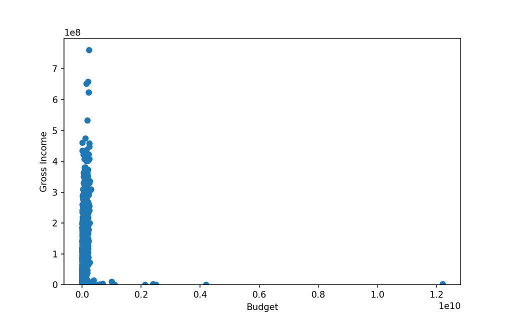

```python
plt.scatter(df['budget'], df['gross'])
plt.xlabel('Budget')
plt.ylabel('Gross Income')
```

### *Barplot* barplot with a groupby

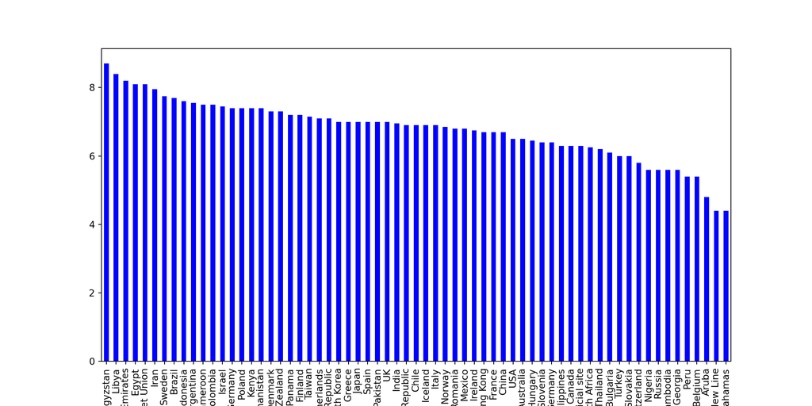

```python
plt.figure(figsize = (12,6))
df.groupby('country')['imdb_score'].median().sort_values(ascending=False).plot.bar(color = 'b')
```

### Plotting Functions

```python
X=np.linspace(0,4*3.14,101)
Y=np.sin(X)
plt.plot(X,Y,'.')
```

### Plotting Features

```python
plt.figure(figsize=(12,6)) #figsize must be first declaration
plt.plot(x,y,'g.-',markersize=20, linewidth=4,alpha=0.4,label='data1')
plt.plot(x,y2,'.--',color='red',markersize=10,alpha=0.7,linewidth=0.3,label='data2')
plt.legend(loc=1)
plt.title('Example Plot')
plt.xlabel('horizontal axis')
plt.ylabel('vertical axis')
plt.xlim(6,12)
plt.ylim(0,10)
plt.xticks([6,9,12])
plt.yticks([0,4,8])
plt.text(10,2,'some text',color='blue',size=14)
plt.show()
```

## Seaborn

```python
import seaborn as sns
titanic=sns.load_dataset('titanic')
```

```python
sns.countplot(x="deck", data=titanic);
plt.hist(titanic['deck'].dropna());
sns.stripplot(x="sex",y="age",data=titanic)
sns.swarmplot(x="sex",y="age",data=titanic)
sns.barplot(x="sex",y="survived", data=titanic)
sns.barplot(x="sex",y="survived", hue='class', data=titanic)
```

# R

## Markdown

### Formatting

For basic formatting for your output HTML document  
(how to update your YAML Preamble):

https://bookdown.org/yihui/rmarkdown/html-document.html

### Themes:

https://www.datadreaming.org/post/r-markdown-theme-gallery/

### Code Chunk

https://yihui.org/knitr/options/

### Advanced Themes:

https://cran.r-project.org/web/packages/rmdformats/readme/README.html

### LaTex:

https://joshua.smcvt.edu/undergradmath/undergradmath.pdf

### HTML

colors, fonts, etc… (most tags will not work if placed around codechunks, or will not work as expected)

https://daringfireball.net/projects/markdown/syntax

## Functions

```r
cost_per_person <- function(people, bill) {
  tax = bill * 0.07
  tip = bill * 0.18
  total = bill + tax + tip
  costPP = total / people
  return(costPP)
}
```

```r
cost_per_person(5, 221.78)
```

```
## [1] 55.445
```

```r
cost_per_person(4, 221.78)
```

```
## [1] 69.30625
```

### Default Arguments

```r
xyz = function(x=1, y, z=1) {
  return(x * 100 + y * 10 + z)
}
```

### Built In Functions

```r
set.seed(0) # For reproducible results
x = rnorm(1000, mean=2) # Random sample from a normal distribution

mean(x) # mean of x
```

```
## [1] 1.98417
```

```r
median(x) # median of x
```

```
## [1] 1.941129
```

```r
var(x) # variance of x
```

```
## [1] 0.9960137
```

```r
sd(x) # standard deviation of x
```

```
## [1] 0.9980048
```

```r
quantile(x, c(0.25, 0.50, 0.75)) # quantiles of x
```

```
##      25%      50%      75%
## 1.291544 1.941129 2.687639
```

```r
sum(x) # sum of x
```

```
## [1] 1984.17
```

## Working Directory

```r
getwd()
```

```
## [1] "C:/Users/jmeis/NYC_DSA/CheatSheet"
```

```r
#setwd("C:/Users/cmmaf/Desktop/RDA-50/1/Lecture")
#setwd("C:/Users/cmmaf/Desktop/RDA-50")
```

## Reading Files

```r
#full_path = "C:/Users/cmmaf/Desktop/RDA-50/1/Lecture/data/CPS1988.csv"
#CPS1988 = read.csv(full_path, header=TRUE)

#relative_path = "data/CPS1988.csv"
#CPS1988 = read.csv(relative_path, header=TRUE)
library(AER)
data("CPS1988")

dim(CPS1988)
```

```
## [1] 28155     7
```

## Data Frames

### Useful Methods

```r
head(CPS1988)
```

|  | wage | education | experience | ethnicity | smsa | region | parttime |
| --- | --- | --- | --- | --- | --- | --- | --- |
| 1 | 354.94 | 7 | 45 | cauc | yes | northeast | no |
| 2 | 123.46 | 12 | 1 | cauc | yes | northeast | yes |
| 3 | 370.37 | 9 | 9 | cauc | yes | northeast | no |
| 4 | 754.94 | 11 | 46 | cauc | yes | northeast | no |
| 5 | 593.54 | 12 | 36 | cauc | yes | northeast | no |
| 6 | 377.23 | 16 | 22 | cauc | yes | northeast | no |

```r
str(CPS1988, vec.len=5)
```

```
## 'data.frame':    28155 obs. of  7 variables:
##  $ wage      : num  355 123 370 755 594 377 ...
##  $ education : int  7 12 9 11 12 16 8 12 12 14 12 8 ...
##  $ experience: int  45 1 9 46 36 22 51 34 0 18 17 42 ...
##  $ ethnicity : Factor w/ 2 levels "cauc","afam": 1 1 1 1 1 1 1 1 1 1 1 1 ...
##  $ smsa      : Factor w/ 2 levels "no","yes": 2 2 2 2 2 2 2 2 2 2 2 2 ...
##  $ region    : Factor w/ 4 levels "northeast","midwest",..: 1 1 1 1 1 1 1 1 1 1 1 1 ...
##  $ parttime  : Factor w/ 2 levels "no","yes": 1 2 1 1 1 1 1 1 1 1 1 1 ...
```

```r
head(CPS1988$region)
```

```
## [1] northeast northeast northeast northeast northeast northeast
## Levels: northeast midwest south west
```

### Slicing Data Frames

```r
str(CPS1988, vec.len=1)
```

```
## 'data.frame':    28155 obs. of  7 variables:
##  $ wage      : num  355 ...
##  $ education : int  7 12 ...
##  $ experience: int  45 1 ...
##  $ ethnicity : Factor w/ 2 levels "cauc","afam": 1 1 ...
##  $ smsa      : Factor w/ 2 levels "no","yes": 2 2 ...
##  $ region    : Factor w/ 4 levels "northeast","midwest",..: 1 1 ...
##  $ parttime  : Factor w/ 2 levels "no","yes": 1 2 ...
```

```r
CPS1988$wage[1:8]
```

```
## [1] 354.94 123.46 370.37 754.94 593.54 377.23 284.90 561.13
```

```r
CPS1988[["wage"]][1:8]
```

```
## [1] 354.94 123.46 370.37 754.94 593.54 377.23 284.90 561.13
```

```r
CPS1988["wage"]
```

|  | wage |
| --- | --- |
| 1 | 354.94 |
| 2 | 123.46 |
| 3 | 370.37 |
| 4 | 754.94 |
| 5 | 593.54 |
| 6 | 377.23 |
| 7 | 284.90 |
| 8 | 561.13 |
| 9 | 264.06 |
| 10 | 1643.83 |

[output cut: 9990 more lines]

```r
CPS1988[c("wage", "education")]
```

|  | wage | education |
| --- | --- | --- |
| 1 | 354.94 | 7 |
| 2 | 123.46 | 12 |
| 3 | 370.37 | 9 |
| 4 | 754.94 | 11 |
| 5 | 593.54 | 12 |
| 6 | 377.23 | 16 |
| 7 | 284.90 | 8 |
| 8 | 561.13 | 12 |
| 9 | 264.06 | 12 |
| 10 | 1643.83 | 14 |

[output cut: 9990 more lines]

```r
# Use $ to get individual columns out as vectors
CPS1988$wage[1:6]
```

```
## [1] 354.94 123.46 370.37 754.94 593.54 377.23
```

```r
CPS1988$education[1:6]
```

```
## [1]  7 12  9 11 12 16
```

```r
# We can use brackets as well, however since df's have 2 dimensions df[ROWS, COLUMNS]

# Returns a df, first 10 rows and columns 2 and 4
CPS1988[1:10, c(2,4)]
```

|  | education | ethnicity |
| --- | --- | --- |
| 1 | 7 | cauc |
| 2 | 12 | cauc |
| 3 | 9 | cauc |
| 4 | 11 | cauc |
| 5 | 12 | cauc |
| 6 | 16 | cauc |
| 7 | 8 | cauc |
| 8 | 12 | cauc |
| 9 | 12 | cauc |
| 10 | 14 | cauc |

```r
CPS1988[1:10, c('education', 'ethnicity')]
```

|  | education | ethnicity |
| --- | --- | --- |
| 1 | 7 | cauc |
| 2 | 12 | cauc |
| 3 | 9 | cauc |
| 4 | 11 | cauc |
| 5 | 12 | cauc |
| 6 | 16 | cauc |
| 7 | 8 | cauc |
| 8 | 12 | cauc |
| 9 | 12 | cauc |
| 10 | 14 | cauc |

```r
# All rows but for the educ and exper columns
CPS1988[c('education', 'experience')]
```

|  | education | experience |
| --- | --- | --- |
| 1 | 7 | 45 |
| 2 | 12 | 1 |
| 3 | 9 | 9 |
| 4 | 11 | 46 |
| 5 | 12 | 36 |
| 6 | 16 | 22 |
| 7 | 8 | 51 |
| 8 | 12 | 34 |
| 9 | 12 | 0 |
| 10 | 14 | 18 |

[output cut: 9990 more lines]

```r
#CPS1988[ , c('education', 'experience')]
```

```r
# If you get only one column, it will be a vector
class(CPS1988[, 1])
```

```
## [1] "numeric"
```

```r
class(CPS1988[, 1:2])
```

```
## [1] "data.frame"
```

```r
CPS1988["wage"]
```

|  | wage |
| --- | --- |
| 1 | 354.94 |
| 2 | 123.46 |
| 3 | 370.37 |
| 4 | 754.94 |
| 5 | 593.54 |
| 6 | 377.23 |
| 7 | 284.90 |
| 8 | 561.13 |
| 9 | 264.06 |
| 10 | 1643.83 |

[output cut: 9990 more lines]

```r
CPS1988[1]
```

|  | wage |
| --- | --- |
| 1 | 354.94 |
| 2 | 123.46 |
| 3 | 370.37 |
| 4 | 754.94 |
| 5 | 593.54 |
| 6 | 377.23 |
| 7 | 284.90 |
| 8 | 561.13 |
| 9 | 264.06 |
| 10 | 1643.83 |

[output cut: 9990 more lines]

## Lists

```r
myVec = 1:10
```

```r
myMat = matrix(1:12, ncol=3)
```

```r
myDf = CPS1988[1:10, ]
```

```r
myList = list(myVec, myMat, myDf)
myList
```

```
## [[1]]
##  [1]  1  2  3  4  5  6  7  8  9 10
##
## [[2]]
##      [,1] [,2] [,3]
## [1,]    1    5    9
## [2,]    2    6   10
## [3,]    3    7   11
## [4,]    4    8   12
##
## [[3]]
##       wage education experience ethnicity smsa    region parttime
## 1   354.94         7         45      cauc  yes northeast       no
## 2   123.46        12          1      cauc  yes northeast      yes
## 3   370.37         9          9      cauc  yes northeast       no
## 4   754.94        11         46      cauc  yes northeast       no
## 5   593.54        12         36      cauc  yes northeast       no
## 6   377.23        16         22      cauc  yes northeast       no
## 7   284.90         8         51      cauc  yes northeast       no
## 8   561.13        12         34      cauc  yes northeast       no
## 9   264.06        12          0      cauc  yes northeast       no
## 10 1643.83        14         18      cauc  yes northeast       no
```

```r
namedList = list(A=myVec, B=myMat, C=myDf)
namedList$D = pi

namedList['E'] = exp(1)

namedList
```

```
## $A
##  [1]  1  2  3  4  5  6  7  8  9 10
##
## $B
##      [,1] [,2] [,3]
## [1,]    1    5    9
## [2,]    2    6   10
## [3,]    3    7   11
## [4,]    4    8   12
##
## $C
##       wage education experience ethnicity smsa    region parttime
## 1   354.94         7         45      cauc  yes northeast       no
## 2   123.46        12          1      cauc  yes northeast      yes
## 3   370.37         9          9      cauc  yes northeast       no
## 4   754.94        11         46      cauc  yes northeast       no
## 5   593.54        12         36      cauc  yes northeast       no
## 6   377.23        16         22      cauc  yes northeast       no
## 7   284.90         8         51      cauc  yes northeast       no
## 8   561.13        12         34      cauc  yes northeast       no
## 9   264.06        12          0      cauc  yes northeast       no
## 10 1643.83        14         18      cauc  yes northeast       no
##
## $D
## [1] 3.141593
##
## $E
## [1] 2.718282
```

## Control Flow

### IF

```r
num = 5
# Note: %% is the Modulo (remainder) operation
if (num %% 2 != 0) {
  cat(num, 'is odd')
}
```

```
## 5 is odd
```

```r
num = 5

if (num %% 2 != 0) {
  cat(num, 'is odd')
  # more commands
} else {
  cat(num, 'is even')
  # more commands
}
```

```
## 5 is odd
```

```r
set.seed(0)
age = sample(0:100, 20, replace=TRUE)
age
```

```
##  [1] 13 67 38  0 33 86 42 13 81 58 50 96 84 20 53 73  6 72 78 84
```

```r
res = ifelse(age > 70,
             'old',
             ifelse(age <= 30,
                    'young',
                    'mid'))
res
```

```
##  [1] "young" "mid"   "mid"   "young" "mid"   "old"   "mid"   "young" "old"
## [10] "mid"   "mid"   "old"   "old"   "young" "mid"   "old"   "young" "old"
## [19] "old"   "old"
```

### FOR

```r
library(readr)
sign_data = read.csv("TimesSquareSignage.csv", header=TRUE)
obs = nrow(sign_data)
for (i in 1:obs) {
  if (is.na(sign_data$Width[i])) {
    cat('WARNING: Missing width for sign no.', i, '\n')
  }
}
```

### While

```r
i = 1
while (i <= obs) {
  if (is.na(sign_data$Width[i])) {
    cat('WARNING: Missing width for sign no.', i, '\n')
  }
  i = i + 1
}
```

## Dplyr

### Tibble

```r
library(dplyr)
births_df = read.csv("C:/Users/jmeis/RDA_054/Lecture 2/data/births.csv", stringsAsFactors=FALSE)
bnames_df = read.csv("C:/Users/jmeis/RDA_054/Lecture 2/data/bnames.csv", stringsAsFactors=FALSE)
births = as_tibble(births_df)
bnames = as_tibble(bnames_df)
```

### Select, Filter, Arrange

```r
bnames %>%
  select( year, name, prop) %>%
  filter( name == 'Justin') %>%
  arrange(desc(prop)) %>%
  head(2)
```

| year | name | prop |
| --- | --- | --- |
| 1988 | Justin | 0.017519 |
| 1987 | Justin | 0.016162 |

### Mutate, Transmute, Summarise

```r
bnames %>%
  mutate(., newCol = year *2) %>%
  transmute(newCol = newCol/2) %>%
  summarise(sum = sum(newCol/n()))
```

| sum |
| --- |
| 1944 |

### Joins

```r
x = data.frame(
  name = c("John", "Paul", "George", "Ringo", "Stuart", "Pete"),
  instrument = c("guitar","bass","guitar","drums","bass","drums"))
y = data.frame(
  name = c("John", "Paul", "George", "Ringo", "Brian"),
  band = c(TRUE, TRUE, TRUE, TRUE, FALSE))
left_join(x, y, by = "name")
```

| name | instrument | band |
| --- | --- | --- |
| John | guitar | TRUE |
| Paul | bass | TRUE |
| George | guitar | TRUE |
| Ringo | drums | TRUE |
| Stuart | bass | NA |
| Pete | drums | NA |

```r
right_join(x, y, by = "name")
```

| name | instrument | band |
| --- | --- | --- |
| John | guitar | TRUE |
| Paul | bass | TRUE |
| George | guitar | TRUE |
| Ringo | drums | TRUE |
| Brian | NA | FALSE |

```r
inner_join(x, y, by = "name")
```

| name | instrument | band |
| --- | --- | --- |
| John | guitar | TRUE |
| Paul | bass | TRUE |
| George | guitar | TRUE |
| Ringo | drums | TRUE |

```r
full_join(x, y, by="name")
```

| name | instrument | band |
| --- | --- | --- |
| John | guitar | TRUE |
| Paul | bass | TRUE |
| George | guitar | TRUE |
| Ringo | drums | TRUE |
| Stuart | bass | NA |
| Pete | drums | NA |
| Brian | NA | FALSE |

```r
semi_join(x, y, by = "name")
```

| name | instrument |
| --- | --- |
| John | guitar |
| Paul | bass |
| George | guitar |
| Ringo | drums |

```r
anti_join(x, y, by = "name")
```

| name | instrument |
| --- | --- |
| Stuart | bass |
| Pete | drums |

### Group_by

```r
totals = bnames %>%
  group_by(name) %>%
  summarise(total = n())

head(totals)
```

| name | total |
| --- | --- |
| Aaden | 1 |
| Aaliyah | 15 |
| Aarav | 1 |
| Aaron | 138 |
| Ab | 5 |
| Abagail | 10 |

## Shiny

### Links to resources:

HTML Tags https://shiny.rstudio.com/articles/tag-glossary.html Layout Guide https://shiny.rstudio.com/articles/layout-guide.html Functions https://shiny.rstudio.com/reference/shiny/latest/ Widgets https://shiny.rstudio.com/gallery/widget-gallery.html

### Basic Layout (ui.r)

```r
fluidPage(
    titlePanel(...),
    sidebarLayout(
      sidebarPanel(...),
      mainPanel(...)
)
)
```

```r
library(shiny)
library(lubridate)

# Define UI for application that draws a histogram

fluidPage(
  titlePanel("NYC Flights 2014"),
  sidebarLayout(
    sidebarPanel(

      selectizeInput(inputId = "origin",
                    label = "Departure airport",
                     choices = unique(flights$origin)),
      selectizeInput(inputId = "dest",
                     label = "Arrival airport",
                     choices = unique(flights$dest)),
      selectizeInput(inputId = "month",
                     label = "Month",
                     choices = unique(flights$month)
    ),
    mainPanel(tabsetPanel(
      tabPanel('Number of Flights', plotOutput("count")),
      tabPanel('Average Delay', plotOutput("delay"))
    ))
  )
)
```

### Basic Server (server.r)

```r
function(input, output) {
}
```

```r
library(shiny)
library(dplyr)
library(ggplot2)
library(tidyverse)

function(input, output) {
  output$count <- renderPlot(
    flights %>%
      filter(origin == input$origin & dest == input$dest & month == input$month) %>%
      group_by(carrier) %>%
      count() %>%
      ggplot(aes(x = carrier, y = n)) +
      geom_col(fill = "lightblue") +
      ggtitle("Number of flights"))
  output$delay <-renderPlot(
    flights %>%
      filter(origin == input$origin & dest == input$dest & month == input$month) %>%
      group_by(carrier) %>%
      summarise(mean_arr = mean(arr_delay), mean_del = mean(dep_delay)) %>%
      gather(key = metric, value = delay, mean_arr, mean_del)  %>%
      ggplot(aes(x = carrier, y = delay, fill = metric )) +
      geom_col(position = "dodge2") +
      ggtitle('Average Delays')

  )


}
```

### Global .r

```r
#for above example
library(data.table)
flights <- fread(file = "./flights14.csv")
```

# HTML

## Workflow

Start new document index.html with !DOCTYPE

## Parts of HTML Document

<title> </title> <head> </head>  
contains technical info about meta structure of doc  
<body> </body>  
content goes here Lorem# is number of lorem ipsum words to create

## Headers and Paragraphs and divs

<h1> </h1>  
<p> </p>  
<div> </div>

<a href=“about.html”>About</a>

# CSS

for external css create a style.css page

## Inline CSS

<h1 style=“color: olive;font-size: 3rem;”>hello world</h1>

## Internal CSS

<style> h1{  
color:blue;  
font-size: 3rem;  
}  
will change the apperance of all <h1> elments  
will will with spans, body, divs, paragraphs, etc… </style>

## External CSS

### Element selectors and grouping

h1,h2{  
color: red;  
}  
### IDs  
/#heading{  
background:black;  
}  
<h1 id=“heading”>lorem ipsum </h1>

### Class Selectors

.green{  
color:green;  
}  
<h3 class=“green”>I’m green</h3>

### Universal Selector

*{  
background-color:ivory  
}  
Universal selector will be the top level css style, unless overwritten by subsequent styles

### RGBA 0-1 Opacity/Transparency

#<tag>{  
background:rgba(0,0,0,.25)  
<(r value, g value, b value, opacity)>  
}

### Font size, width, height, pixels

{  
font-size: 30px;  
width: 200px;  
height: 300px;  
}

### Percent Value Relative

{  
width: 50%;  
height: 50%;  
}

# SQL

## comments

-- Sytanx for single line comments  
/** multiline comment **/

## *Commands*

### *SHOW <DATABASES> or SHOW <database, or table>;*

shows all databases on server, or shows DB or table

### *USE <database>*

will append database. to every table reference for example:  
`USE movies_db;` is the same as  
`FROM movies_db.tables;`

### *SELECT <rows>*

selects all rows

### *FROM <database>*

noun of the select querry

### *WHERE …*

indicates the condition or conditions that rows must satisfy to be selected.

```
SELECT movie_title,
budget
FROM movies
WHERE budget > 1000000000;
```

### *LIMIT …*

```
SELECT column_names
FROM tabel_names
LIMIT \<offset\> \<count\>;
```

### *AS …*

see column alias

### *CASE WHEN <condition> THEN <result> ELSE <result> END*

```
SELECT movie_title,
CASE
       WHEN title_year > 2014 THEN 'new'
       WHEN title_year BETWEEN 2012 AND 2014 THEN 'new-ish'
ELSE 'old'
END AS movie_age
FROM movies;
```

### *DESCRIBE <object>*

shows column names and values

### *Column Alias*

Select AS

## Mathmatical Operators

+  
-  
*  
/  
Round()

## Comparison Operator

= , equal to  
> , Greater than  
< , less than  
>= , greater than or equal to  
<= , less than or equal to  
<> , != , not equal to

## Logical Operators

### *AND*

Evaluates two conditions and returns True if both are true.

### *OR*

Evaluates two conditions and returns True if at least one is true.

### *BETWEEN…AND…*

Tests value against an inclusive range of values.

```
SELECT movie_title,
title_year BETWEEN 2010 AND 2012 AS year_range
FROM movies;
```

### *IN*

Tests value against a list of values and returns True if value matches at least one in the list.

```
SELECT movie_title,
title_year IN (2010, 2012, 2014) AS year_range,
country IN ('USA', 'UK') AS country_range
FROM movies;
```

### *IS NULL*

Tests value to see if it is null. Return True if null.

### *NOT*

Reverts False to True, and True to False.

## String Manipulation

### *Wildcard Comparisons*

*LIKE* operator in combo with wildcards are used for pattern matching  
% used to define any number of missing characters before and after a pattern  
_ wildcard used to substitute for a single character or space  
example:  
Return True if the country name starts with a ‘U’ else return false

```
SELECT country LIKE 'U%'
FROM MOVIES;
```

```
SELECT country LIKE 'U_A'
FROM MOVIES;
```

## *Functions*

*LOWER()*, *LCASE()* Return string in lowercase  
*UPPER()*, *UCASE()* Return string in uppercase  
*CHAR_LENGTH()* Return number of characters in a string  
*LEFT(, n)* Return the leftmost number of characters specied by n  
*RIGHT(, n)* Return the rightmost number of characters specied by n  
*SUBSTR(, m, n)* Return the number of characters specied by n starting from the m-th position of the string  
*LTRIM()* Return the string with leading spaces removed  
*RTRIM()* Return the string with trailing spaces removed  
*TRIM()* Return the string with leading and trailing spaces removed  
*REPLACE(‘s’, ‘s1’, ‘s2’)* Replaces all the occurrences of a within a string with a new substring  
*COUNT*

```
SELECT count (*)
from \<table name\>;
```

counts all rows

```
SELECT COUNT(column name)
from movies;
```

*SUM*

```
SELECT SUM(title_year IS NULL)
FROM movies;
```

counts number of null values in title year column  
*AVG*

```
Select AVG(title_year IS NULL)
FROM movies;
```

will give the ratio of null values  
*DISTINCT*

```
SELECT COUNT(DISTINCT country)
FROM movies;
```

*MAX*  
Return the maximum value  
*MIN*  
Return the minimum value  
*STD*  
Return the population standard deviation

*VARIANCE*  
Return the population variance

*HAVING*  
used to filter according to result of aggregation

```
SELECT country, COUNT(DISTINCT director_name)
FROM movies
GROUP BY country
HAVING COUNT(DISTINCT director_name) > 5;
```

*UNION*

```
SELECT movie_title, title_year, director_name
FROM movies
WHERE title_year = 1972
UNION
SELECT movie_title, title_year, director_name
FROM movies
WHERE title_year = 1942;
```

*UNION_ALL*  
keeps duplicate records in a union

*JOIN*  
by default is inner_join

```
SELECT expression [, expression ...]
FROM table1 JOIN table2
ON condition-involving-table1-to-table2;
```

```
SELECT *
FROM directors JOIN actors
ON directors.name = actors.name;
```

*LEFT OUTER JOIN*  
select all records from left table and only records on right table that match

```
SELECT * FROM movies LEFT OUTER JOIN directors
ON movies.director_name = directors.name;
```

*FULL OUTER JOIN*  
There is no full outer join command

```
SELECT * FROM movies LEFT OUTER JOIN directors
ON movies.director_name = directors.name
UNION
SELECT * FROM movies RIGHT OUTER JOIN directors
ON movies.director_name = directors.name;
```

*Exclusion Join*  
Let’s say we want to look at directors who are NOT actors. These will be directors who do not fall in the actors table.

```
SELECT * FROM directors LEFT OUTER JOIN actors
ON directors.name = actors.name
WHERE actors.name IS NULL;
```

## GROUP BY

```
SELECT country, AVG(imdb_score)
FROM movies
GROUP BY country;
```

show the average imdb score for each country

```
SELECT country, COUNT(DISTINCT director_name)
FROM movies
GROUP BY country;
```

shows number of directors in each country

WHERE key word is used before group by  
HAVING is used after group by

### *Multiple GROUP BYs*

```
SELECT country, title_year, COUNT(*)
FROM movies
GROUP BY country, title_year;
gives the number of movies in each country per year
```

## ORDER BY

```
SELECT country
FROM movies
ORDER BY country;
```

or

```
SELECT country, language
FROM movies
ORDER BY country, language DESC;
```

## Order of Evaluation

1 FROM  
2 WHERE  
3 GROUP BY  
4 HAVING  
5 SELECT

## Subqueries

- A subquery is a SQL statement that has another SQL query embedded in the WHERE or the HAVING clause.
- The syntax for a subquery when the embedded SQL statement is part of the WHERE condition is as follows:

```
SELECT expressions
FROM tables
WHERE conditions [Comparison Operators]
(SELECT expressions
FROM tables
WHERE conditions);
```

- [Comparison Operators] could be equality operators such as =, >, <, >=, and <=. It can also be a text operator such as “LIKE”.
- The second select clause is considered as the “inner query,” while the rst select clause is considered as the “outer query.”

Example: we want to find the highest avaerage rating from greouped genres

```
SELECT MAX(average.avg_rating)
FROM (
    SELECT AVG(imdb_score) AS avg_rating
    FROM movies
    GROUP BY genres
) AS average;
```

### *ALL*

Compares a value to ervery value from the result table  
example: the following query returns all of the action movies that have a higher IMDB score than the best fantasy movie:

```
SELECT *
FROM movies
WHERE genres = 'Action'
AND imdb_score > ALL
    (SELECT imdb_score
    FROM movies
    WHERE genres = 'Fantasy');
```

### *EXISTS*

The EXISTS operator checks if the row from the subquery matches any row in the outer query. If there’s no data matched, the EXISTS operator returns FALSE.  
The following query returns all the movies that are directed by director who are born after 01/01/1980.

```
SELECT movie_title
FROM movies
WHERE EXISTS (SELECT *
    FROM directors
    WHERE directors.name = movies.director_name
    AND birthday > '1980-01-01')
```

## *Windows Functions*

### *RANK() OVER*

```
SELECT
    gross, RANK() OVER (ORDER BY gross)
    FROM movies
    WHERE gross IS NOT NULL;
```

### *Cutting with NTILE()*

A very common analytical method is to cut numeric values into a few categories.NTILE could help us to do so:

```
SELECT
gross,
NTILE(5) OVER (ORDER BY gross DESC) AS tier
  FROM movies
  WHERE gross IS NOT NULL;
```

breaks into 5 teirs

### *Cumulative Sums*

```
SELECT gross,
RANK() OVER (ORDER BY gross) AS _rank,
SUM(gross) OVER (ORDER BY gross) AS cum_sum,
AVG(gross) OVER (ORDER BY gross) AS cum_avg
FROM movies
WHERE gross IS NOT NULL;
```

### *Lag and rolling values*

```
SELECT
    gross,
  AVG(gross) OVER (ORDER BY gross) AS cum_avg,
  AVG(gross) OVER (
    ORDER BY gross
        ROWS BETWEEN 2 PRECEDING AND CURRENT ROW
      ) AS moving_avg
FROM movies
WHERE gross IS NOT NULL;
```

the moving average takes the average of the current row ans the 2 previous

```
SELECT
    gross,
  LAG(gross) OVER(ORDER BY gross) AS delay,
  gross - LAG(gross) OVER(ORDER BY gross) AS diff,
  (gross - LAG(gross) OVER(ORDER BY gross))/gross AS rate
FROM movies
WHERE gross IS NOT NULL;
```

*LAG* function will generate the previous rows value LAG(<column>, # to lag) defaults to 1

## PARTITION

Rank facebook likes by tier

```
SELECT tier, movie_title,
    RANK() OVER
    (PARTITION BY tier ORDER BY movie_facebook_likes DESC)
FROM (
    SELECT
      movie_title, num_critic_for_reviews,
      movie_facebook_likes, budget,
      gross, NTILE(5) OVER (ORDER BY gross DESC) AS tier
FROM movies
WHERE gross IS NOT NULL
) Q;
```

## CREATE TABLE

```
CREATE TABLE table_name (
column_name column_type [options],
...
)
```

example

```
CREATE TABLE actors (
biography VARCHAR(6000),
birthday DATE DEFAULT NULL,
deathday DATE DEFAULT NULL,
gender INT DEFAULT NULL,
name VARCHAR(255),
place_of_birth VARCHAR(255),
facebook_likes INT DEFAULT NULL
);
```

for more options/flags  
https://dev.mysql.com/doc/refman/5.7/en/create-table.html

### *INSERT*

```
INSERT INTO table_name
(column_name_1, column_name_2, ...)
VALUES
(value_row1_col1, value_row1_col2, ...),
(value_row2_col1, value_row2_col2, ...),
...
;
```

```
INSERT INTO actors
(birthday,deathday,gender,name,place_of_birth,facebook_likes)
VALUES
("1942-08-17",NULL,0,"Roshan Seth","Patna, Bihar, India",61.0);
```

### *UPDATE*

```
UPDATE table_name SET column_name = new_value
[WHERE where_condition];
```

set SQL into safe updates mode first `SET SQL_SAFE_UPDATES = 0;`

```
UPDATE actors SET facebook_likes = 68
WHERE name = "Roshan Seth";
```

### *DELETE*

```
DELETE FROM tbl_name
[WHERE where_condition];
```

### *TRUNCATE*

to empty a table

```
TRUNCATE TABLE table_name;
```

### *DROP*

to fully remove a table

```
DROP TABLE table name;
```

## Create Temporary Table

```
select
  select list
into
  # temporary table name (name must start with hashtag)
from
  table_name
where
  criteria
```

## SQL Command Line Prompt

in command line  
`mysql -u<username(no space)> -p<password>`

## LOAD data

from my SQL command line

```
LOAD DATA LOCAL INFILE file_name
INTO TABLE table_name
FIELDS TERMINATED BY string_1 ENCLOSED BY string_2
LINES TERMINATED BY string_3
IGNORE int LINES
;
```

## Data Integrity

### *Primary Key*

```
CREATE TABLE actors (
biography varchar(6000),
birthday date DEFAULT NULL,
deathday date DEFAULT NULL,
gender int DEFAULT NULL,
name varchar(255),
place_of_birth varchar(255),
facebook_likes int DEFAULT NULL,
PRIMARY KEY (name)
);
```

### *Foreign key*

```
ALTER TABLE child_table
ADD CONSTRAINT constraint_name
FOREIGN KEY index_col_name
REFERENCES parent_table(index_col_name);
```

```
ALTER TABLE movies
ADD CONSTRAINT FK_ActorMovie
FOREIGN KEY (actor_1_name) REFERENCES actors(name);
```

### *CASCADE* or *SET NULL*

When you try to delete or change a record that is a primary or foreign key in a table must set cascade ON DELETE CASCADE will change all child records ON DELETE SET NULL - will set null in all child records

## Example Exercises

- Find the average lost of the movies which actually lost money for each country.

```
SELECT country, AVG(gross - budget)
FROM movies
WHERE (gross - budget) < 0
GROUP BY country;
```

```
SELECT country, AVG(gross - budget)
FROM movies
GROUP BY country
HAVING AVG(gross - budget) > 0;
```

- Show the languages and the count of the movies in which each language is spoken. Order the result by the count.

```
select language,
    count(*)
from movies
group by language
order by count(*) desc;
```

- Find how many records are in each of the tables of the previous example from performing both UNION and UNION ALL on the actors and directors tables.

```
SELECT COUNT(*) FROM (
SELECT name, birthday FROM actors
UNION
SELECT name, birthday FROM directors
) AS union_table;
```

- Exercise: How many people are both directors and actors in the dataset?

[output not shown]

- Find the number of directors who are not also in the actors table

```
select * from directors left outer join actors
on directors.name = actors.name
where actors.name is null;
```

- find the number of actors who are not in the directors table

```
select * from actors left outer join directors
on actors.name = directors.name
where directors.name is null;
```

- the number of people who are both directors and actors.

```
select * from actors inner join directors
on actors.name = directors.name
```

- Find all the directors who’s facebook_likes are in the top 10 facebook_likes from directors table.

```
SELECT name, facebook_likes
FROM directors
WHERE facebook_likes >= (
    SELECT facebook_likes
    FROM directors
    ORDER BY facebook_likes DESC
    LIMIT 1 OFFSET 9 -- n-1 here for the top n.
)
ORDER BY facebook_likes DESC;
```

- Find the average facebook likes and critics reviews for each of 5 tiers of profitability of the movies DB

```
SELECT tier,
    AVG(num_critic_for_reviews) AS avg_critics,
    AVG(movie_facebook_likes) AS avg_flikes
FROM (
    SELECT
        movie_title, num_critic_for_reviews,
        movie_facebook_likes, budget,
        gross, NTILE(5) OVER (ORDER BY gross DESC) AS tier
    FROM movies
    WHERE gross IS NOT NULL
) Q
GROUP BY Q.tier;
```

### *Concatenation*

CONCAT ( <col name>, <col name>,…)

## Date Manipulation

### Functions

*CURRENT_DATE()* Return current date.  
*CURRENT_TIME()* Return current time.  
*DATE()* Extract the date part of a date or datetime expression.  
*DAY()*, *DAYOFMONTH()* Return the day of the month (1- 31)  
*DAYOFWEEK()* Return the weekday index of a date or datetime expression.  
*MONTH()* Return the month part of a date or datetime expression.  
*YEAR()* Return the year part of a date or datetime expression.  
*DATE_ADD(date, INTERVAL value add unit)*  
Adds a time/date interval to a date and then returns the date

# Docker

## Images

- An executable package that includes everything needed to run an application: code, runtime, libraries, environment variable configuration files
- can build your own

can find images at https://www.dockerhub.com

## Container

- a runtime instance of a image - is what the image becomes in memory when executed
- once you have the image pulled you can start the container from the docker engine
- containers isolate software from its environment.

## Commands

### *List all images*

docker image ls

### *Delete a file*

rm

### *Continue command on new line*

^

### *Pull an image*

docker pull <docker IMAGE>

### *Remove image from computer*

docker image rm -f <IMAGE ID>

### *Run a container*

docker run -it -d –rm ^  
-p hostPort:containerPort ^  
-v host-dir:container-dir ^  
(actual example  
docker run -it –rm ^  
-p 8890:8888 ^  
-v %cd%:/home/ubuntu/Workspace ^  
nycdsa/linux-toolkits) cd is the current directory  
<docker IMAGE>  
bash

### *Options*

-it runs a container in interactive processes.  
-d (optional) runs a container in the background in detached mode.  
–rm (optional) removes the container when it exits or when the daemon exits.  
-p hostPort:containerPort (optional) forwards a container᾿s port to the host.  
-v host-dir:container-dir (optional) mounts a host directory into a container directory so files can be shared between them.  
bash (optional) starts the command line of the container in the terminal.Depending how the image was built, you may or may not need it.

### *Inspect running elements*

docker ps

### *Inspect stopped containers*

docker ps -a

### *Stop a container*

exit

### *Remove a stopped container*

docker container rm

only need to specify enough characters of the container to uniquely identify it

### *Restart and Log back into container*

docker restart

docker exec -it bash

# General Windows Terminal

## Commands

### *Echo*

echo prints  
### *Change Directory*  
cd  
### *list files and directories*  
dir

# Linux

## Commands

date (gets date)

ssh (loginto remote server)

scp (copy from or to a remote machine)

wget or curl (download a webpage)

### *Command help*

command –help

### *Show entire file system*

ls

### *Change directories*

cd

cd or cd ~ changes to home directory

cd .. changes to parent folder

### *Make DIrectory*

mkdir

mkdir -p ~/examples/multiple/levels/down

(-p makes multiple nested directories regardless of weather parts of the specified path exist)

### *Copy file or Folder*

cp [-r]

-r argument means recursively for copying folders

copy a file into home directory; note the .  
$ cp /etc/magic .  
copy a file into home directory with a new name  
$ cp /etc/hosts nethosts  
$ ls

### *Move or rename files*

mv

### *Move curser and keyboard shortcuts*

ctrl + a (begginging of line)  
crtl + e (end of line)  
crtl + u (delete line) Tab (auto-complete)

### *Remove files*

rm rmdir or rm -r (removes empty folders)

### *Quick create file*

touch

### *I/O redirection*

> create  
>> append

### *Print Files or show contents*

cat head  
less Scroll up/down one line at a time with arrow keys.  
Use the space bar to scroll through a screen at a time.  
Use the / key to search for a term: /apple  
Press h to see a quick list of other options.  
Press q to exit less.

### *Download file*

wget

### *File permissions*

ls - l (long format) to show permissions

The permissions are broken into 4 sections. For example: drwxr-xr–

Where ‘r’-> read, ‘w’-> write/delete, ‘x’-> execute, ‘-’-> no permission

### *Show command line format*

echo $PS1 (PS1-4 exist)

### *change command prompt*

export PS1 = “\u \t:$”

will change prompt to user name and time followed by ":$"

### *Clear screen*

crtl + L

### *Stop process*

crtl + C

### *Stop Program*

crtl + D

### *print working dirrectory*

pwd

### *Relative Path*

./ (is current directory)

### *Parent Directory*

../

### *home directory*

~

### *show where a file is*

which

### *change permission*

write = 2

execute = 1

read = 4

chmod 744

owner will be given 7 permission (sum of 4 + 1 + 2)

### *Text Processing*

grep - Search through a given file using a string

grep [<file2]>

wc - Count lines and words

outputs lines/words/characters

sort - Sort all lines in file

sort -k9 (key)(column 9 (counts from 1))

sort -k5 -n (sorts 5th column which contains numbers)

# VI

## commands

### *Open vi*

vi  
will open filename or create it if it doesnt exist

### *insert mode*

I

a - insert after cursor

i - insert before cursor

o - insert a new line below

O - insert a new line above

ESC - exit insert mode

### *command mode*

esc

x - delete one character  
dw - delete one word  
dd - delete the line  
D - delete the rest of the line  
u - undo the last action

### *exit VI*

ZZ save file and exit(capital letters)  
:wq (save and quit)  
:w save without exiting  
:q! exit without saving

# Git

## workflow

### *pull repo from remote*

-git init  
or  
-git clone  
write code  
-git add  
is now in staging area  
-git commit  
commit changes and opens editor to add a comment  
write code  
-git add  
-git commit -m “messasge” revert changed git checkout or <head~ID>  
brings us to a detached head state  
-git checkout master (or main)  
reattaches head  
for checkouts that could cause conflicts  
-git revert  
resolve conflicts  
-git add .  
-git commit -m “message”  
prepare to push to github  
change wd out of project repo  
create repo on github  
copy repo URL from ‘code’ button  
-git clone  
-git push

## Commands

### *git init*

convert an existing, unversioned project to a Git repository or initialize a new empty repository.

### *git clone*

copies an existing Git repository

### *git status*

show status of all tracked and untracked files

### *git log*

full status of git commands –stat includes a brief summary  
–oneline (condense each commit to a single line)  
–graph –decorate To include branches and the ref names:

### *git reflog*

get complete history in repo

### *git add*

starts tracking  
git add . (adds all files)

### *git commit*

commit changes  
-m “message”  
-a does the add as well as commit

### *git show*

see changes that were made to tracked files  
git show to see textual differences  
git show HEAD reference to the currently checked-out commit/branch.  
git show HEAD~2 shows the second commit message

### *git checkout –*

discard changes in working directory  
git checkout HEAD~2

### *git diff*

To see what you’ve changed but not yet staged

### *git restore –staged*

to unstage

### *git reset*

permanetly reverts code to hash ID

### *Config*

git config –global user.name “name”  
git config –global user.email email@email

# Resources

Books for free: Data Science at the Command line  
https://datascienceatthecommandline.com/  
Practical Statistics for Data Science https://largepdf.net/practical-statistics-for-data-scientists-50-essential-concepts-using-r-and-python/  
Bayesian Methods for hackers https://freecomputerbooks.com/Bayesian-Methods-for-Hackers.html